# Assignment 3

### Problem 1: Data Augmentation

1. CIFAR10 is a pretty straightforward image classification task, that consists of 10 visual object classes.
2. Download them from here1 and be ready to use it. Both PyTorch and Tensorflow have options to conveniently load them, but I chose to download them directly and mess around because I found it easier.
3. Set aside 5,000 training examples for validation.
4. Build your baseline CNN classifier.

(a) The images need to be reshaped into 32 × 32 × 3 tensors.

(b) Each pixel is an integer with 8bit encoding (from 0 to 255). Transform them down to a floating point with a range [0, 1]. 0 means a black pixel and 1 is a white one.

(c) People like to rescale the pixels to [-1, 1] so that the input to the CNN is well centered around 0, instead of 0.5.

(d) I know you are eager to try out a fancier net architecture, but let’s stick to this simple one:

```
   1st 2d conv layer:  there are 10 kernels whose size is 5x5x3; stride=1
   Maxpooling:  2x2 with stride=2
   1st 2d conv layer:  there are 10 kernels whose size is 5x5x10; stride=1
   Maxpooling:  2x2 with stride=2
   1st fully-connected layer: [flattened final feature map] x 20
   2st fully-connected layer: 20 x 10 Softmax on the 10 classes
   Let’s stick to ReLU for activation and the Kaiming He’s initializer.
```

(e) Train this net with an Adam optimizer with a default initial learning late (i.e. 0.001). Check on the validation accuracy at the end of every epoch. Report your validation accuracy over the epochs as a graph. This is the performance of your baseline system.

#### Loading the libraries

```python
import numpy as np
import tensorflow as tf
import pandas as pd
import matplotlib.pyplot as plt
import seaborn as sns
from matplotlib.pyplot import imshow
import keras
from keras.models import Sequential
from keras.layers.core import Dense, Activation, Dropout
from tensorflow.keras.layers import Activation,Dense,LSTM,Input
from keras.models import Model
from tensorflow.keras import layers
import librosa
import IPython.display as ipd
from tensorflow.keras.layers import Conv2D
from tensorflow.keras.layers import MaxPooling2D
from tensorflow.keras.layers import Flatten
from tensorflow.keras.layers import Input
from keras.callbacks import History
from tensorflow.keras.optimizers import Adam
from tensorflow.keras.metrics import mean_squared_error

from google.colab import drive
drive.mount('/content/drive')
```

#### Loading the data and seperating the last 5000 images for validation

```python
cifar10 = tf.keras.datasets.cifar10
(x_train, y_train), (_, _) = tf.keras.datasets.cifar10.load_data()

# taking last 5000
x_train1 = x_train[0:45000]
y_train1 = y_train[0:45000]
x_val = x_train[45000:50000]
y_val = y_train[45000:50000]
```

```
Downloading data from https://www.cs.toronto.edu/~kriz/cifar-10-python.tar.gz
```

```python
print("Shapes of train and validation set")
x_train1.shape, y_train1.shape, x_val.shape, y_val.shape
```

```
Shapes of train and validation set
```

```
((45000, 32, 32, 3), (45000, 1), (5000, 32, 32, 3), (5000, 1))
```

#### Prepocessing the data

```python
# converting to -1 to +1

x_val=(2*(x_val/255))-1
x_train1=(2*(x_train1/255))-1

# converting labels to categorical

y_train1 = tf.keras.utils.to_categorical(y_train1, num_classes=10)
y_val = tf.keras.utils.to_categorical(y_val, num_classes=10)
```

```python
np.amax(x_train1), np.amin(x_train1)
```

```
(1.0, -1.0)
```

#### Model Architechture

```python
model = Sequential()
model.add(Input(shape = (32,32,3)))
model.add(Conv2D(10, kernel_size=(5,5), activation='relu', strides = 1,kernel_initializer = tf.keras.initializers.HeNormal()))
model.add(MaxPooling2D(pool_size=(2, 2), strides=2))
model.add(Conv2D(10, kernel_size=(5,5), activation='relu',strides = 1,kernel_initializer = tf.keras.initializers.HeNormal()))
model.add(MaxPooling2D(pool_size=(2, 2), strides=2))
model.add(Flatten())
model.add(Dense(20, activation='relu',kernel_initializer = tf.keras.initializers.HeNormal()))
model.add(Dense(10, activation='softmax',kernel_initializer = tf.keras.initializers.HeNormal()))

model.compile(optimizer=tf.keras.optimizers.Adam(learning_rate=0.001),loss='categorical_crossentropy', metrics=['accuracy'])
print(model.summary())
```

```
Model: "sequential_1"
_________________________________________________________________
Layer (type)                 Output Shape              Param #
=================================================================
conv2d_2 (Conv2D)            (None, 28, 28, 10)        760
_________________________________________________________________
max_pooling2d_2 (MaxPooling2 (None, 14, 14, 10)        0
_________________________________________________________________
conv2d_3 (Conv2D)            (None, 10, 10, 10)        2510
_________________________________________________________________
max_pooling2d_3 (MaxPooling2 (None, 5, 5, 10)          0
_________________________________________________________________
flatten_1 (Flatten)          (None, 250)               0
_________________________________________________________________
dense_2 (Dense)              (None, 20)                5020
_________________________________________________________________
dense_3 (Dense)              (None, 10)                210
=================================================================
Total params: 8,500
Trainable params: 8,500
Non-trainable params: 0
_________________________________________________________________
None
```

#### Fitting on the training data and checking the validation loss

```python
# fit the keras model on the dataset
model.fit(x_train1, y_train1, batch_size=64, epochs=200, validation_data=(x_val, y_val),callbacks=[history])
```

```
<keras.callbacks.History at 0x7f256e375850>
```

#### Validation loss and storing the data

```python
hist = history.history
val_accuracy = hist['val_accuracy']

baseline_data=pd.DataFrame(val_accuracy,columns=['data'])
baseline_data.to_csv ("/content/drive/MyDrive/Deep Learning Assignment/baseline_data.csv")
```

1. Build another classifier using an augmented dataset. Prepare four different datasets out of the original CIFAR10 training set (except for the 5,000 you set aside for validation):

(a) I know you already changed the scale of the pixels from [0,255] to [-1,+1]. Let’s go back to the intermediate range, [0,1].

(b) Augmented dataset #1: Brighten every pixel in every image by 10%, e.g., by multi- plying 1.1. Make sure though, that they don’t exceed 1. For example, you may want to do something like this: np.minimum(1.1*X, 1).

(c) Augmented dataset #2: Darken every pixel in every image by 10%, e.g., by multi- plying 0.9.

(d) Augmented dataset #3: Flip all images horizontally (not upside down, but in the left-right direction). As if they are mirrored.

(e) Augmented dataset #4: The original training set.

(f) Merge the four augmented dataset into one gigantic training set. Since there are 45,000 images in the original training set (after excluding the validation set), after the aug- mentation you have 45,000×4=180,000 images. Each original image has four different versions: brighter, darker, horizontally flipped, and original versions. Note that the four share the same label: a darker frog is still a frog.

(g) Don’t forget to scale back to [-1,+1].

(h) You better visualize a few images after the augmentation to make sure what you did is correct.

(i) Train a fresh new network with the same architecture, but using this augmented dataset. Record the validation accuracy over the epochs.

#### Data Augmentation

```python
# Scaling the train data to 0 to 1
x_train_norm = x_train1/255

# Scaling the validation data to -1 to 1
x_val=(2*(x_val/255))-1
```

##### Augmented dataset 1: Brighten

```python
x_train_bright = np.minimum(1.1*x_train_norm, 1)
```

##### Augmented dataset 2: Darken

```python
x_train_darken = 0.9*x_train_norm
```

```python
x_train_mirror = np.fliplr(x_train_norm)
```

```
Clipping input data to the valid range for imshow with RGB data ([0..1] for floats or [0..255] for integers).
```

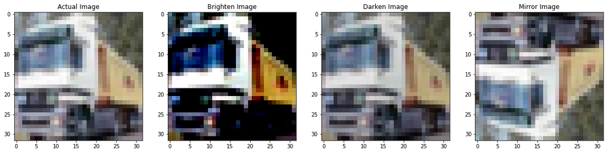

```python
# plotting images to check the rotations:
fig, (ax1, ax2, ax3, ax4) = plt.subplots(1,4)
fig.set_figheight(5)
fig.set_figwidth(20)
ax1.imshow(x_train1[1], interpolation='nearest')
ax1.set_title("Actual Image")
ax2.imshow(x_train_bright[1], interpolation='nearest')
ax2.set_title("Brighten Image")
ax3.imshow(x_train_darken[1], interpolation='nearest')
ax3.set_title("Darken Image")
ax4.imshow(x_train_mirror[1], interpolation='nearest')
ax4.set_title("Mirror Image")

plt.show()
```

```python
# Scaling to -1 to 1
x_train_bright = (2*(x_train_bright/np.amax(x_train_bright)))-1
x_train_darken = (2*(x_train_darken/np.amax(x_train_darken)))-1
x_train_mirror = (2*(x_train_mirror/np.amax(x_train_mirror)))-1
x_train_norm = (2*(x_train_norm/np.amax(x_train_norm)))-1

# Concating the data frames
x_train_concat = np.vstack((x_train_norm,x_train_mirror,x_train_darken,x_train_bright))
y_train_concat = np.vstack((y_train1,y_train1,y_train1,y_train1))
```

```python
print("Shape of X_train", x_train_concat.shape)
print("Shape of Y_train", y_train_concat.shape)
```

```
Shape of X_train (180000, 32, 32, 3)
Shape of Y_train (180000, 10)
```

```python
print("Shape of Val_X", x_val.shape)
print("Shape of Val_Y", y_val.shape)
```

```
Shape of Val_X (5000, 32, 32, 3)
Shape of Val_Y (5000, 10)
```

#### Model Architechture

```python
model = Sequential()
model.add(Input(shape = (32,32,3)))
model.add(Conv2D(10, kernel_size=(5,5), activation='relu', strides = 1,kernel_initializer = tf.keras.initializers.HeNormal()))
model.add(MaxPooling2D(pool_size=(2, 2), strides=2))
model.add(Conv2D(10, kernel_size=(5,5), activation='relu',strides = 1,kernel_initializer = tf.keras.initializers.HeNormal()))
model.add(MaxPooling2D(pool_size=(2, 2), strides=2))
model.add(Flatten())
model.add(Dense(20, activation='relu',kernel_initializer = tf.keras.initializers.HeNormal()))
model.add(Dense(10, activation='softmax',kernel_initializer = tf.keras.initializers.HeNormal()))

model.compile(optimizer=tf.keras.optimizers.Adam(learning_rate=0.001),loss='categorical_crossentropy', metrics=['accuracy'])
print(model.summary())
```

```
Model: "sequential"
_________________________________________________________________
Layer (type)                 Output Shape              Param #
=================================================================
conv2d (Conv2D)              (None, 28, 28, 10)        760
_________________________________________________________________
max_pooling2d (MaxPooling2D) (None, 14, 14, 10)        0
_________________________________________________________________
conv2d_1 (Conv2D)            (None, 10, 10, 10)        2510
_________________________________________________________________
max_pooling2d_1 (MaxPooling2 (None, 5, 5, 10)          0
_________________________________________________________________
flatten (Flatten)            (None, 250)               0
_________________________________________________________________
dense (Dense)                (None, 20)                5020
_________________________________________________________________
dense_1 (Dense)              (None, 10)                210
=================================================================
Total params: 8,500
Trainable params: 8,500
Non-trainable params: 0
_________________________________________________________________
None
```

```python
# fit the keras model on the dataset
history = History()
model.fit(x_train_concat, y_train_concat, batch_size=128, epochs=200, validation_data=(x_val, y_val),callbacks=[history])
```

```
<keras.callbacks.History at 0x7fb78b30bdd0>
```

```python
# Store the validation data
hist = history.history
val_accuracy = hist['val_accuracy']

augmented_data=pd.DataFrame(val_accuracy,columns=['data'])
augmented_data.to_csv ("/content/drive/MyDrive/Deep Learning Assignment/augmented_data.csv")
```

```python
val_accuracy_base = pd.read_csv("/content/drive/MyDrive/Deep Learning Assignment/baseline_data.csv")
augmented_data = pd.read_csv("/content/drive/MyDrive/Deep Learning Assignment/augmented_data.csv")
```

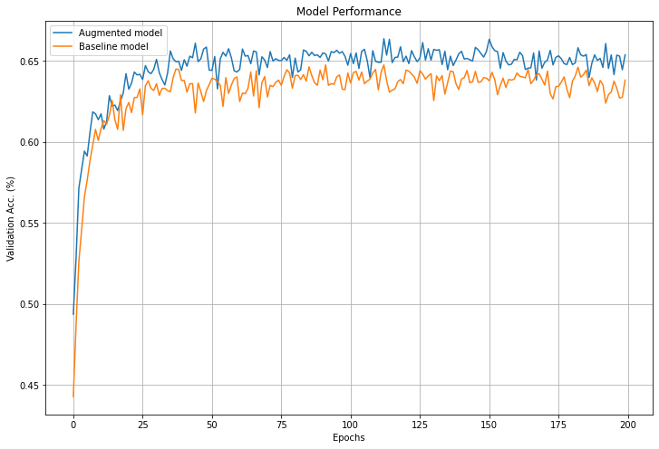

```python
plt.figure(figsize=(12,8))
plt.plot(augmented_data['data'],label='Augmented model')
plt.plot(val_accuracy_base['data'], label = 'Baseline model')
plt.xlabel('Epochs')
plt.ylabel('Validation Acc. (%)')
plt.title('Model Performance')
plt.legend()
plt.grid()
```

##### From the above the validation accuracy graph for baseline model and augmented data model, we can see that the performance of augmented data is comparitevly better than the baseline model. Theortically it should be the case as we are adding more amount of data to the model for training and doing the augmentation make our model robost to the changes in the image

### Problem 2: Self-Supervised Learning via Pretext Tasks

1. Suppose that you have only 50 labeled examples per class for your CIFAR10 classification problem, totaling 500 training images. Presumably it might be tough to achieve a high performance in this situation. Set aside those 500 examples from your training set (I chose the last 500 examples).
2. The pretext task:

(a) We will try to improve this situation by learning from unlabeled dataset.

(b) We will assume that the rest of the 49,500 training examples are unlabeled. We will create a bogus classification problem using them. Let this unlabeled examples (or the examples that you disregard their original labels) be “class 0”.

(c) “class 1”: Create a new class, by vertically flipping all the images upside down.

(d) “class 2”: Create another class, by rotating the images 90 degree counter-clock wise.

(e) Now you have three classes, each of which contains 49,500 examples that are with made- up labels.

(f) This is not a classification problem anywhere near the original CIFAR10 problem. But, the idea here is that a classifier, that is trained to solve this problem, may need to learn some helpful features for the original CIFAR10 classification problem.

(h) Store your model somewhere safe. Both TF and PT provide a nice way to save the net parameters.

```python
cifar10 = tf.keras.datasets.cifar10
(x_train, y_train), (x_test, y_test) = tf.keras.datasets.cifar10.load_data()

# taking last 500
x_train1 = x_train[0:49500]
y_train1 = y_train[0:49500]
x_val = x_train[49500:50000]
y_val = y_train[49500:50000]

# xtrain label
class_0 = np.full((x_train1.shape[0],1), 0)
```

### Pretext Task

#### Class:1 Vertical flip

```python
train_vertical = []
for img in x_train1:
  train_vertical.append(list(np.flipud(img)))

train_vertical=np.array(train_vertical)
class_1 = np.full((train_vertical.shape[0],1), 1)
```

#### Class:2 90 rotation

```python
train_rotate=[]
for img in x_train1:
  train_rotate.append(list(np.rot90(img)))

train_rotate=np.array(train_rotate)
class_2 = np.full((train_rotate.shape[0],1), 2)
```

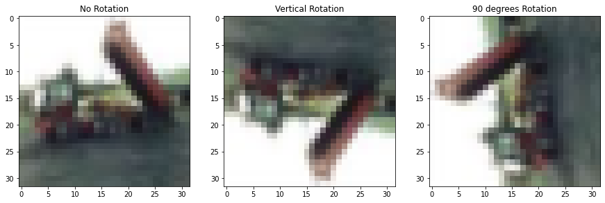

```python
# plotting images to check the rotations:
fig, (ax1, ax2, ax3) = plt.subplots(1,3)
fig.set_figheight(5)
fig.set_figwidth(15)
ax1.imshow(x_train1[2], interpolation='nearest')
ax1.set_title("No Rotation")
ax2.imshow(train_vertical[2], interpolation='nearest')
ax2.set_title("Vertical Rotation")
ax3.imshow(train_rotate[2], interpolation='nearest')
ax3.set_title("90 degrees Rotation")
plt.show()
```

```python
# concating the matrix
x_train_concat = np.vstack((x_train1, train_vertical, train_rotate))
y_train_concat = np.vstack((class_0, class_1, class_2))

# scaling to -1 to 1
x_train_concat = (2*(x_train_concat/255)-1)

# one hot encoding
y_train_concat = tf.keras.utils.to_categorical(y_train_concat, num_classes=3)
```

#### Model Architechture

```python
model = Sequential()
model.add(Input(shape = (32,32,3)))
model.add(Conv2D(10, kernel_size=(5,5), activation='relu', strides = 1,name = "conv_layer1",kernel_initializer = tf.keras.initializers.HeNormal()))
model.add(MaxPooling2D(pool_size=(2, 2), name = "max_pool1", strides=2))
model.add(Conv2D(10, kernel_size=(5,5), name = "conv_layer2",activation='relu',strides = 1,kernel_initializer = tf.keras.initializers.HeNormal()))
model.add(MaxPooling2D(pool_size=(2, 2), name = "max_pool2", strides=2))
model.add(Flatten(name = "flatten"))
model.add(Dense(20, activation='relu', name = "FC1", kernel_initializer = tf.keras.initializers.HeNormal()))
model.add(Dense(3, activation='softmax', name = "FC2", kernel_initializer = tf.keras.initializers.HeNormal()))

model.compile(optimizer=tf.keras.optimizers.Adam(learning_rate=0.001),loss='categorical_crossentropy', metrics=['accuracy'])

print(model.summary())
```

```
Model: "sequential"
_________________________________________________________________
Layer (type)                 Output Shape              Param #
=================================================================
conv_layer1 (Conv2D)         (None, 28, 28, 10)        760
_________________________________________________________________
max_pool1 (MaxPooling2D)     (None, 14, 14, 10)        0
_________________________________________________________________
conv_layer2 (Conv2D)         (None, 10, 10, 10)        2510
_________________________________________________________________
max_pool2 (MaxPooling2D)     (None, 5, 5, 10)          0
_________________________________________________________________
flatten (Flatten)            (None, 250)               0
_________________________________________________________________
FC1 (Dense)                  (None, 20)                5020
_________________________________________________________________
FC2 (Dense)                  (None, 3)                 63
=================================================================
Total params: 8,353
Trainable params: 8,353
Non-trainable params: 0
_________________________________________________________________
None
```

```python
# fit the keras model on the dataset
history = History()
model.fit(x_train_concat, y_train_concat, batch_size=512, epochs=100,callbacks=[history])
```

```
<keras.callbacks.History at 0x7f29b3cd1290>
```

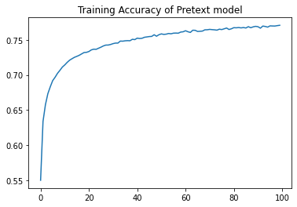

```python
hist = history.history
accuracy = hist['accuracy']
plt.plot(accuracy)
#plt.ylim((0,1))
plt.title('Training Accuracy of Pretext model');
```

##### Saving the model weights

```python
model.save_weights('/content/drive/MyDrive/Deep Learning Assignment/pretext_weights',save_format='h5')
#model.save(filepath='/content/drive/MyDrive/Deep Learning Assignment/pretext_model.h5')
```

#### Baseline

(a) Train a classifier from scratch on the 500 CIFAR10 dataset you set aside in the begining. Note that they are for the original 10-class classification problem, and you ARE doing the original CIFAR10 classification, except that you use a ridiculously small amount of dataset. Let’s stick to the same architecture/setup. You may need to choose a reasonable initializer, e.g., the He initializer. You know, since the training set is too small, you may not even have to do batching.

(b) Let’s cheat here and use the test set of 10,000 examples as if they are our validation set. If you check on the test accuracy at every 100th epoch, you will see it overfit at some point. Record the accuracy values over iterations.

```python
y_test.shape, y_val.shape
```

```
((10000, 1), (500, 1))
```

##### Preprocess the data

```python
# scaling to -1 to 1
x_val = (2*(x_val/255)-1)
x_test = (2*(x_test/255)-1)

# one hot encoding
y_val = tf.keras.utils.to_categorical(y_val, num_classes=10)
y_test = tf.keras.utils.to_categorical(y_test, num_classes=10)
```

##### Model Architechture

```python
model = Sequential()
model.add(Input(shape = (32,32,3)))
model.add(Conv2D(10, kernel_size=(5,5), activation='relu', strides = 1,name = "conv_layer1",kernel_initializer = tf.keras.initializers.HeNormal()))
model.add(MaxPooling2D(pool_size=(2, 2), name = "max_pool1", strides=2))
model.add(Conv2D(10, kernel_size=(5,5), name = "conv_layer2",activation='relu',strides = 1,kernel_initializer = tf.keras.initializers.HeNormal()))
model.add(MaxPooling2D(pool_size=(2, 2), name = "max_pool2", strides=2))
model.add(Flatten(name = "flatten"))
model.add(Dense(20, activation='relu', name = "FC1", kernel_initializer = tf.keras.initializers.HeNormal()))
model.add(Dense(10, activation='softmax', name = "FC2", kernel_initializer = tf.keras.initializers.HeNormal()))


model.compile(optimizer=tf.keras.optimizers.Adam(learning_rate=0.001),loss='categorical_crossentropy', metrics=['accuracy'])
print(model.summary())
```

```
Model: "sequential_1"
_________________________________________________________________
Layer (type)                 Output Shape              Param #
=================================================================
conv_layer1 (Conv2D)         (None, 28, 28, 10)        760
_________________________________________________________________
max_pool1 (MaxPooling2D)     (None, 14, 14, 10)        0
_________________________________________________________________
conv_layer2 (Conv2D)         (None, 10, 10, 10)        2510
_________________________________________________________________
max_pool2 (MaxPooling2D)     (None, 5, 5, 10)          0
_________________________________________________________________
flatten (Flatten)            (None, 250)               0
_________________________________________________________________
FC1 (Dense)                  (None, 20)                5020
_________________________________________________________________
FC2 (Dense)                  (None, 10)                210
=================================================================
Total params: 8,500
Trainable params: 8,500
Non-trainable params: 0
_________________________________________________________________
None
```

```python
# fit the keras model on the dataset
history = History()
model.fit(x_val, y_val, batch_size=500, epochs=10000, validation_data=(x_test, y_test),callbacks=[history], validation_freq = 100,verbose = 0)
```

```
<keras.callbacks.History at 0x7f29b3998950>
```

##### Extracting the train and validation accuracy

```python
hist = history.history
train_accuracy = hist['accuracy'][::100]
val_accuracy = hist['val_accuracy']
```

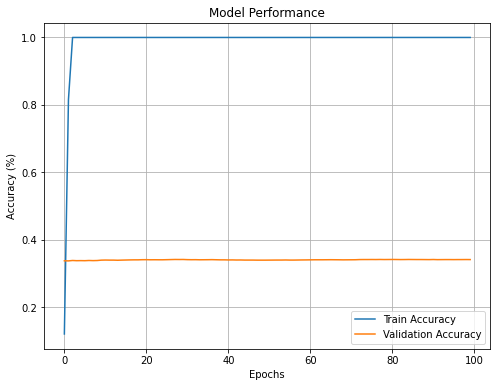

```python
plt.figure(figsize=(8,6))
#plt.plot(augmented_data['data'],label='Augmented model')
#plt.plot(val_accuracy_base['data'], label = 'Baseline model')
plt.plot(train_accuracy, label = "Train Accuracy")
plt.plot(val_accuracy, label = "Validation Accuracy")
plt.xlabel('Epochs')
plt.ylabel('Accuracy (%)')
plt.title('Model Performance')
plt.legend()
plt.grid()
```

```python
# Dumping the data
baseline = pd.DataFrame(list(zip(train_accuracy, val_accuracy)),
               columns =['train_accuracy', 'val_accuracy'])
baseline.to_csv ("/content/drive/MyDrive/Deep Learning Assignment/baseline.csv")
```

### Transfer learning task

(a) Let’s train our third classifier on the 500 CIFAR10 dataset you set aside in the begining. Again, note that they are for the original 10-class classification problem.

(b) This time, instead of using an initializer, you will reload the weights from the pretext network you learned in P2.2. Yes, that’s exactly the definition of transfer learning. But, because you learned it from an unlabeled set, and had to create a pretext task to do so, it falls in the category of self-supervised learning.

(c) Note that you can trasfer all the parameters in except for the final softmax layer, as the pretext task is only with 3 classes. Let’s randomly initialize this last softmax layer parameters with He.

(d) Optimize the network as if you trained it from scratch. You need to reduce the learning rates for transfer learning in general. More importantly, for the ones you transfer in, they have to be substantially lower than 1 × 10−3, e.g. 1 × 10−5or1 × 10−6. Meanwhile, the last softmax layer will prefer the default learning rate 1 × 10−3, as it’s randomly initialized.

(e) Report your test accuracy at every 100th epoch.

##### Model Architechture

```python
model = Sequential()
model.add(Input(shape = (32,32,3)))
model.add(Conv2D(10, kernel_size=(5,5), activation='relu', strides = 1,name = "conv_layer1"))
model.add(MaxPooling2D(pool_size=(2, 2), name = "max_pool1", strides=2))
model.add(Conv2D(10, kernel_size=(5,5), name = "conv_layer2",activation='relu',strides = 1))
model.add(MaxPooling2D(pool_size=(2, 2), name = "max_pool2", strides=2))
model.add(Flatten(name = "flatten"))
model.add(Dense(20, activation='relu', name = "FC1"))
model.add(Dense(10, activation='softmax', name = "FC2_v1", kernel_initializer = tf.keras.initializers.HeNormal()))

print(model.summary())


#model.compile(optimizer=tf.keras.optimizers.Adam(learning_rate=0.001),loss='mse')
```

```
Model: "sequential_3"
_________________________________________________________________
Layer (type)                 Output Shape              Param #
=================================================================
conv_layer1 (Conv2D)         (None, 28, 28, 10)        760
_________________________________________________________________
max_pool1 (MaxPooling2D)     (None, 14, 14, 10)        0
_________________________________________________________________
conv_layer2 (Conv2D)         (None, 10, 10, 10)        2510
_________________________________________________________________
max_pool2 (MaxPooling2D)     (None, 5, 5, 10)          0
_________________________________________________________________
flatten (Flatten)            (None, 250)               0
_________________________________________________________________
FC1 (Dense)                  (None, 20)                5020
_________________________________________________________________
FC2_v1 (Dense)               (None, 10)                210
=================================================================
Total params: 8,500
Trainable params: 8,500
Non-trainable params: 0
_________________________________________________________________
None
```

```python
#!pip install tensorflow-addons
import tensorflow_addons as tfa
```

[output not shown]

##### Using different learning for layers where we are taking weights from pretext model

```python
optimizers = [
    tf.keras.optimizers.Adam(learning_rate=1e-7),
    tf.keras.optimizers.Adam(learning_rate=1e-3)
]

optimizers_and_layers = [(optimizers[0], model.layers[0]),(optimizers[0], model.layers[2]),(optimizers[0], model.layers[5]), (optimizers[1], model.layers[6])]
optimizer = tfa.optimizers.MultiOptimizer(optimizers_and_layers)

model.compile(optimizer=optimizer,loss='categorical_crossentropy',metrics=['accuracy'])
```

##### Loading the weights from pretext model

```python
model.load_weights('/content/drive/MyDrive/Deep Learning Assignment/pretext_weights',by_name=True)
#model.load_weights('/content/drive/MyDrive/Deep Learning Assignment/pretext_model.h5',by_name=True)
```

```python
history = History()
model.fit(x_val, y_val,validation_data=(x_test,y_test),epochs=10000,callbacks=[history],batch_size=512,validation_freq=100, verbose = 0)
```

```
<keras.callbacks.History at 0x7f29b0ffb910>
```

##### Extracting train and validation accuracy

```python
hist = history.history
train_accuracy = hist['accuracy'][::100]
val_accuracy = hist['val_accuracy']
```

```python
val_accuracy1=pd.DataFrame(val_accuracy1,columns=['data'])
val_accuracy1.to_csv ("/content/drive/MyDrive/Deep Learning Assignment/transfer_learning.csv")
```

```python
val_accuracy1 = pd.read_csv("/content/drive/MyDrive/Deep Learning Assignment/transfer_learning.csv")
baseline = pd.read_csv("/content/drive/MyDrive/Deep Learning Assignment/baseline.csv")
```

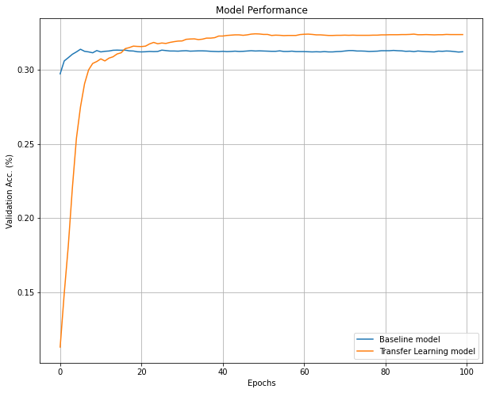

```python
plt.figure(figsize=(10,8))
#plt.plot(augmented_data['data'],label='Augmented model')
#plt.plot(val_accuracy_base['data'], label = 'Baseline model')
plt.plot(baseline['val_accuracy'], label = 'Baseline model')
plt.plot(val_accuracy1['data'], label = "Transfer Learning model")
plt.xlabel('Epochs')
plt.ylabel('Validation Acc. (%)')
plt.title('Model Performance')
plt.legend()
plt.grid()
```

### Problem 3: Speech Denoising Using RNN

##### Path for Train, Validation and Test

```python
import os

path='/content/drive/MyDrive/Deep Learning Assignment/timit-homework'

train_path =path +'/tr/'
test_path = path + '/te/'
val_path =path+'/v/'

train_files =os.listdir(train_path)
test_files =os.listdir(test_path)
val_files=os.listdir(val_path)

trx=sorted([ file for file in train_files if file.startswith('trx')])
trs=sorted([ file for file in train_files if file.startswith('trs')])
trn=sorted([ file for file in train_files if file.startswith('trn')])

vx=sorted([ file for file in val_files if file.startswith('vx')])
vs=sorted([ file for file in val_files if file.startswith('vs')])
vn=sorted([ file for file in val_files if file.startswith('vn')])

tex=sorted([ file for file in test_files if file.startswith('tex')])
```

```python
## Due to some reason the uploaded audio file got duplicated so to remove it I used the below code
trx1 = [i  for i in trx if "(1)" not in i]
trs1 = [i  for i in trs if "(1)" not in i]
trn1 = [i  for i in trn if "(1)" not in i]

vx1 = [i  for i in vx if "(1)" not in i]
vs1 = [i  for i in vs if "(1)" not in i]
vn1 = [i  for i in vn if "(1)" not in i]

tex1 = [i  for i in tex if "(1)" not in i]
```

#### Loading the file and doing stft

```python
def loading_files(path, files):
  spectogram = []
  spectogram_mag = []
  for file in tqdm(files):
    s, sr = librosa.load(path+file, sr=None)
    S=librosa.stft(s, n_fft=1024, hop_length=512)
    spectogram.append(S)
    s_abs = np.abs(S)
    spectogram_mag.append(s_abs)
    del s,S,s_abs
  return spectogram, spectogram_mag
```

```python
X_tr_spect, X_tr = loading_files(train_path, trx1)
S_tr_spect, S_tr = loading_files(train_path, trs1)
N_tr_spect, N_tr = loading_files(train_path, trn1)
```

```python
X_val_spect, X_val = loading_files(val_path, vx1)
S_val_spect, S_val = loading_files(val_path, vs1)
N_val_spect, N_val = loading_files(val_path, vn1)
```

##### Padding the train and validation data

```python
def padding(matrix):
  for i in range(len(matrix)):
    pad = 10 - (matrix[i].shape[1] % 10)
    small_value = np.random.normal(0,0.00001, size = [matrix[i].shape[0],int(pad)])
    matrix[i] = np.concatenate((matrix[i],small_value), axis = 1)

padding(X_tr)
padding(S_tr)
padding(N_tr)

padding(X_val)
padding(S_val)
padding(N_val)
```

##### IBM matrix

```python
Mask=[]
for signal, noise in zip(S_tr,N_tr):
  Mask.append((signal>noise)*1)

Mask_val=[]
for signal, noise in zip(S_val,N_val):
  Mask_val.append((signal>noise)*1)
```

##### Creating batches

```python
def batches(X):
  batch = []
  for arr in X:
    arr2 = []
    for col in range(arr.shape[1]//10):
      temp_arr = arr[:,10*col:10*col+10]
      arr2.append(temp_arr)
    arr2 = np.array(arr2)
    batch.append(arr2)
  return np.concatenate(batch)

X_tr_batch = batches(X_tr)
X_val_batch = batches(X_val)

Mask_batch = batches(Mask)
Mask_batch_val = batches(Mask_val)
```

##### Model Architechture

```python
model = Sequential()
model.add(Input(shape=(None,513)))
model.add(LSTM(activation='relu',units=1024,return_sequences=True,name='layer_1', kernel_initializer='he_normal'))
model.add(LSTM(activation='relu',units=1024,return_sequences=True,name='layer_2', kernel_initializer='he_normal'))
model.add(LSTM(activation='relu',units=1024,return_sequences=True,name='layer_3', kernel_initializer='he_normal'))
model.add(Dense(units = 513, activation='sigmoid', name = "FC2_v1", kernel_initializer = tf.keras.initializers.HeNormal()))

model.compile(loss='binary_crossentropy',optimizer='adam')
print(model.summary())
```

```
WARNING:tensorflow:Layer layer_1 will not use cuDNN kernels since it doesn't meet the criteria. It will use a generic GPU kernel as fallback when running on GPU.
WARNING:tensorflow:Layer layer_2 will not use cuDNN kernels since it doesn't meet the criteria. It will use a generic GPU kernel as fallback when running on GPU.
WARNING:tensorflow:Layer layer_3 will not use cuDNN kernels since it doesn't meet the criteria. It will use a generic GPU kernel as fallback when running on GPU.
Model: "sequential_1"
_________________________________________________________________
Layer (type)                 Output Shape              Param #
=================================================================
layer_1 (LSTM)               (None, None, 1024)        6299648
_________________________________________________________________
layer_2 (LSTM)               (None, None, 1024)        8392704
_________________________________________________________________
layer_3 (LSTM)               (None, None, 1024)        8392704
_________________________________________________________________
FC2_v1 (Dense)               (None, None, 513)         525825
=================================================================
Total params: 23,610,881
Trainable params: 23,610,881
Non-trainable params: 0
_________________________________________________________________
None
```

```python
history = model.fit(np.transpose(X_tr_batch,(0,2,1)), np.transpose(Mask_batch,(0,2,1)),
                    validation_data=(np.transpose(X_val_batch,(0,2,1)), np.transpose(Mask_batch_val,(0,2,1))),
                    epochs = 50, batch_size = 512)
```

```python
# Saved the model
model.save(filepath='/content/drive/MyDrive/Deep Learning Assignment/denoising2.h5')
```

```python
# load the model
model = keras.models.load_model('/content/drive/MyDrive/Deep Learning Assignment/denoising2.h5')
```

```
WARNING:tensorflow:Layer lstm will not use cuDNN kernels since it doesn't meet the criteria. It will use a generic GPU kernel as fallback when running on GPU.
WARNING:tensorflow:Layer lstm_1 will not use cuDNN kernels since it doesn't meet the criteria. It will use a generic GPU kernel as fallback when running on GPU.
WARNING:tensorflow:Layer lstm_2 will not use cuDNN kernels since it doesn't meet the criteria. It will use a generic GPU kernel as fallback when running on GPU.
```

##### Validation set

```python
X_val_spect1, X_val1 = loading_files(val_path, vx1)
S_val_spect1, S_val1 = loading_files(val_path, vs1)
N_val_spect1, N_val1 = loading_files(val_path, vn1)
```

```python
S_val_pred = []
for i in tqdm(range(len(X_val_spect1))):
    x_val_spect = X_val_spect1[i]
    x_val_abs = X_val1[i]
    m_pred = np.round(model.predict(x_val_abs.T.reshape([1,-1,513])).squeeze())
    s_pred = (m_pred.T)*x_val_spect
    S_val_pred.append(s_pred)
```

```python
def snr(clean,prediction):
    clean = clean[:len(prediction)]
    prediction = prediction[:len(clean)]
    return 10*np.log10(np.divide(np.square(clean).sum(), np.square(clean - prediction).sum()))
```

```python
def snr_validation(S_list,S_p_list):
    snr_arr = np.zeros(len(S_list))
    for i in range(len(S_list)):
        S = S_list[i]
        S_p = S_p_list[i]
        s = librosa.istft(S, hop_length=512)
        s_p = librosa.istft(S_p, hop_length=512)
        snr_i = snr(s,s_p)
        snr_arr[i] = snr_i
    return np.mean(snr_arr)
```

##### SNR value of validation

```python
snr_validation(S_val_spect1, S_val_p)
```

```
10.168793328665197
```

##### Testing

```python
!mkdir test_cleaned
```

```python
X_test_spect, X_test = loading_files(test_path, tex1)
```

```python
def file_name(i,prefix):
    i_str = str(i)
    return prefix+'0000'[:-len(i_str)]+i_str
```

```python
import soundfile as sf
S_te_p = []
for i in tqdm(range(len(X_test_spect))):
    x_te = X_test_spect[i]
    x_te_abs = X_test[i]
    m_te_p = np.round(model.predict(x_te_abs.T.reshape([1,-1,513])).squeeze())
    s_te_p = (m_te_p.T)*x_te
    S_te_p.append(s_te_p)
    s = librosa.istft(s_te_p, hop_length=512)
    fname = file_name(i,'tec')
    sf.write(f'test_cleaned/{fname}.wav', s, sr)
```

```python
tex, sr = librosa.load("/content/drive/MyDrive/Deep Learning Assignment/te/tex0000.wav", sr=None)
tes, sr = librosa.load("/content/drive/MyDrive/Deep Learning Assignment/test_cleaned/tec0000.wav", sr=None)
```

##### Audio with noise

```python
ipd.Audio(tex, rate = sr)
```

[interactive chart not shown]

#### Audio after removing noise

```python
ipd.Audio(tes, rate = sr)
```

[interactive chart not shown]

```python
!zip -r test_cleaned.zip test_cleaned
```

[output not shown]

[output cut: 346 more lines]

[output not shown]